# Lending Tree Scenario

This documents explores a different approach to matching inventory (a consumer request) and inventory (what lenders have to offer).

Let’s load some test data and take a look at it:

```
## Observations: 40,000
## Variables: 10
## $ campaignNames        (chr) "Campaign 1", "Campaign 2", "Campaign 3",...
## $ lenderNames          (chr) "Lender 199", "Lender 368", "Lender 163",...
## $ productNames         (chr) "Purchase", "Auto", "ReFi", "Auto", "Home...
## $ loanAmtLenderMax     (int) 312000, 296000, 300000, 251000, 246000, 3...
## $ minLenderCreditScore (int) 720, 670, 750, 740, 690, 630, 690, 630, 6...
## $ eyeClors             (chr) "Brown", "Brown", "Hazel", "Blue", "Hazel...
## $ state                (chr) "California", "Kansas", "Maryland", "Alab...
## $ veteran              (chr) "No", "No", "No", "No", "No", "No", "Yes"...
## $ foreclosure          (chr) "No", "Yes", "Yes", "No", "Yes", "No", "N...
## $ capacity             (int) 20, 5, 48, 17, 0, 35, 18, 32, 26, 36, 24,...
```

There are 40000 records in this dataset with 10 named fields It can easily scale to millions of records and as many fields as you can imagine.

Assuming this record set includes all the available campaigns at a lending institution called AWE Money Tree. m AWE Money Tree has a internet presence where it attracts customers in need of money. Let’s see what happens on any given day at AWE Money Tree.

AWE Money Tree often changes its web based consumer experience in attempt to please the customers while maximizing revenue, margin or lender close rates. Today, AWE Money Tree has changed its experience to first ask for how much money the consumer needs to borrow. (Yesterday AWE Money Tree asked what kind of loan the consumer wanted.)

Betty Sue Linda Studebaker begins to answer the questions on the AWE Money Tree web form:

Betty Sue wants to borrow $360000. When this amount is entered, AWE Money Tree instantly filters all the available campaigns that match this request. Unbeknownst to Betty Sue, the 40000 campaigns at the start of the day has already been reduced to 39223 because some of the campaigns have already reached their capacity. (This is what happens to the consumers that ask for money later in the day.)

By the way, here are the remaining campaigns:

```
##    lenderNames  campaignNames loanAmtLenderMax minLenderCreditScore
## 1    Lender 86   Campaign 510           369000                  560
## 2   Lender 135  Campaign 5532           365000                  710
## 3   Lender 220 Campaign 12296           363000                  740
## 4   Lender 226 Campaign 15015           369000                  690
## 5    Lender 31 Campaign 16134           385000                  600
## 6   Lender 304 Campaign 19990           374000                  690
## 7    Lender 54 Campaign 21169           374000                  680
## 8   Lender 366 Campaign 21185           364000                  670
## 9   Lender 283 Campaign 21644           388000                  700
## 10   Lender 12 Campaign 23565           364000                  610
## 11  Lender 275 Campaign 24581           394000                  660
## 12  Lender 254 Campaign 25193           371000                  640
## 13  Lender 221 Campaign 35620           368000                  680
## 14   Lender 95 Campaign 37163           362000                  690
```

There is some really good news. Notice that the remaining campaigns include some pretty low credit scores.

Betty Sue is now asked to provide her credit score. (Today, AWE Money Tree is asking for a self rated score. Also, Betty Sue is a new visitor to the website because AWE Money Tree did not have any internal information on Betty Sue.)

Betty Sue input 710 as her credit score.

```
##    lenderNames  campaignNames loanAmtLenderMax minLenderCreditScore
## 1    Lender 86   Campaign 510           369000                  560
## 2   Lender 135  Campaign 5532           365000                  710
## 3   Lender 226 Campaign 15015           369000                  690
## 4    Lender 31 Campaign 16134           385000                  600
## 5   Lender 304 Campaign 19990           374000                  690
## 6    Lender 54 Campaign 21169           374000                  680
## 7   Lender 366 Campaign 21185           364000                  670
## 8   Lender 283 Campaign 21644           388000                  700
## 9    Lender 12 Campaign 23565           364000                  610
## 10  Lender 275 Campaign 24581           394000                  660
## 11  Lender 254 Campaign 25193           371000                  640
## 12  Lender 221 Campaign 35620           368000                  680
## 13   Lender 95 Campaign 37163           362000                  690
```

At this point AWE Money Tree could ask Betty Sue if she would like to have 13 lenders reach out to her regarding her money needs. AWE Money Tree might also suggest if Betty Sue would like to receive guidance on how to improve her credit score so that more lenders could provide options. (The AWE Money Tree product manager is considering this experience.)

Even better, AWE Money Tree shows Betty Sue that is she reduced her loan Amount to $330000 so the available loan options increases to 33.

```
##    lenderNames  campaignNames loanAmtLenderMax minLenderCreditScore
## 1    Lender 86   Campaign 510           369000                  560
## 2    Lender 77  Campaign 1100           338000                  600
## 3    Lender 81  Campaign 1108           331000                  530
## 4   Lender 147  Campaign 3297           340000                  660
## 5   Lender 316  Campaign 3312           344000                  630
## 6   Lender 135  Campaign 5532           365000                  710
## 7    Lender 13  Campaign 5598           340000                  640
## 8    Lender 86 Campaign 11589           347000                  620
## 9   Lender 226 Campaign 15015           369000                  690
## 10   Lender 31 Campaign 16134           385000                  600
## 11  Lender 100 Campaign 17380           335000                  650
## 12  Lender 179 Campaign 18926           331000                  700
## 13  Lender 178 Campaign 19037           340000                  690
## 14  Lender 304 Campaign 19990           374000                  690
```

[output cut: 19 more lines]

# Appendix

Distribution of Campaign Max Loan Amounts:

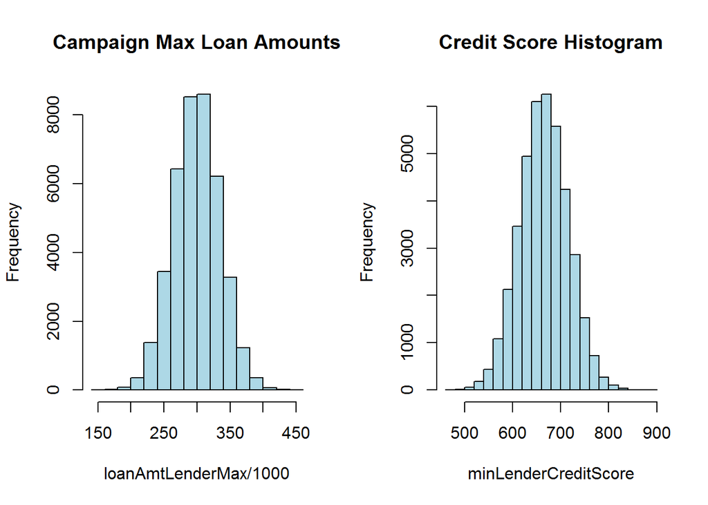

Let’s create a heatmap of the available Lender inventory.

> Sorry, I cannot do it - the code works but the PC runs out of RAM!